# Regression

Jing Fang

# This lecture covers

- Fitting and interpreting linear models

# 7.1 The many faces of regression

# The many faces of regression

- The term *regression* can be confusing because there are so many specialized varieties.
- In addition, R has powerful and comprehensive features for fitting regression models, and the abundance of options can be confusing as well.

# The many faces of regression

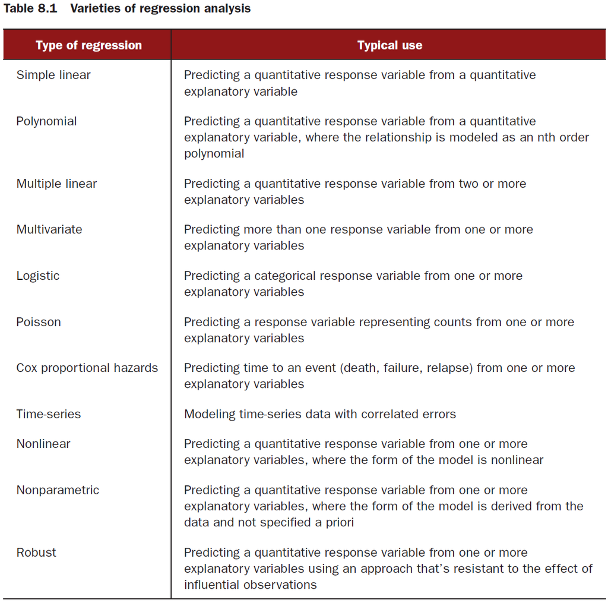

# The many faces of regression

- In this lecture, we’ll focus on regression methods that fall under the rubric of ordinary least squares (OLS) regression, including:
  - simple linear regression,
  - polynomial regression,
  - and multiple linear regression.
- In OLS regression, a quantitative dependent variable is predicted from a weighted sum of predictor variables, where the weights are parameters estimated from the data.
- I’ll describe how to use R functions to fit OLS regression models, evaluate the fit, test assumptions, and select among competing models.

# 7.2 OLS regression

# Fitting regression models with lm()

- In R, the basic function for fitting a linear model is `lm()`.
- The format is `myfit <- lm(formula, data)`
- The formula is typically written as `Y ~ X1 +X2 +...+ Xk`

# Fitting regression models with lm()

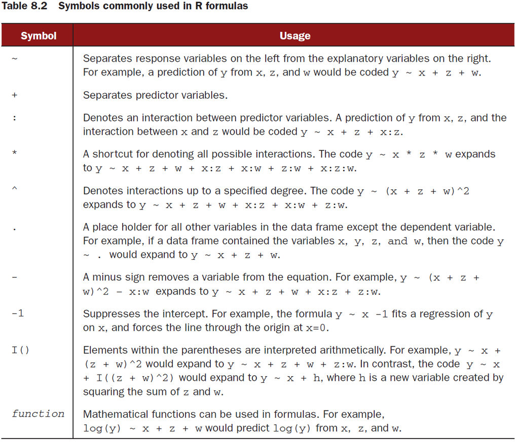

# Fitting regression models with lm()

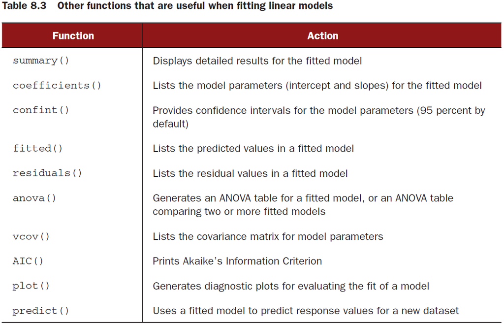

# Simple linear regression

- The dataset women in the base installation provides the height and weight for a set of 15 women ages 30 to 39.
- We want to predict weight from height.

  ```r
  fit = lm(weight ~ height, data = women)
  summary(fit)
  ```

  ```
  ##
  ## Call:
  ## lm(formula = weight ~ height, data = women)
  ##
  ## Residuals:
  ##    Min     1Q Median     3Q    Max
  ## -1.733 -1.133 -0.383  0.742  3.117
  ##
  ## Coefficients:
  ##             Estimate Std. Error t value Pr(>|t|)
  ## (Intercept) -87.5167     5.9369   -14.7  1.7e-09 ***
  ## height        3.4500     0.0911    37.9  1.1e-14 ***
  ## ---
  ## Signif. codes:  0 '***' 0.001 '**' 0.01 '*' 0.05 '.' 0.1 ' ' 1
  ##
  ## Residual standard error: 1.53 on 13 degrees of freedom
  ## Multiple R-squared:  0.991,  Adjusted R-squared:  0.99
  ## F-statistic: 1.43e+03 on 1 and 13 DF,  p-value: 1.09e-14
  ```

# Simple linear regression

```r
women$weight
```

```
##  [1] 115 117 120 123 126 129 132 135 139 142 146 150 154 159 164
```

```r
fitted(fit)
```

```
##     1     2     3     4     5     6     7     8     9    10    11    12
## 112.6 116.0 119.5 122.9 126.4 129.8 133.3 136.7 140.2 143.6 147.1 150.5
##    13    14    15
## 154.0 157.4 160.9
```

```r
residuals(fit)
```

```
##        1        2        3        4        5        6        7        8
##  2.41667  0.96667  0.51667  0.06667 -0.38333 -0.83333 -1.28333 -1.73333
##        9       10       11       12       13       14       15
## -1.18333 -1.63333 -1.08333 -0.53333  0.01667  1.56667  3.11667
```

# Simple linear regression

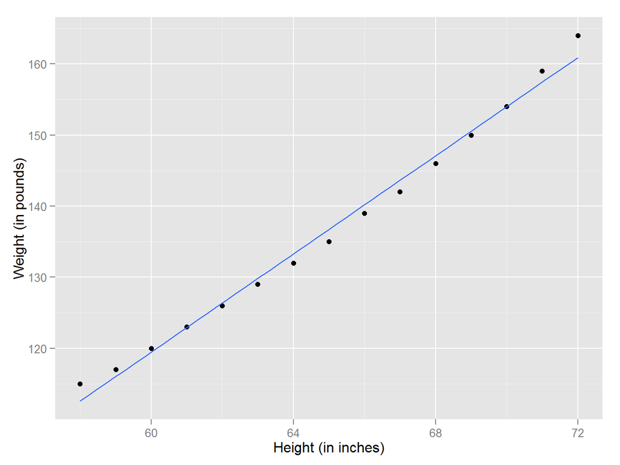

```r
library(ggplot2)
qplot(height, weight, data = women, geom = c("point", "smooth"), method = "lm",
    se = FALSE, xlab = "Height (in inches)", ylab = "Weight (in pounds)")
```

# Testing a linear hypothesis

- The standard regression output as provided by `summary()` only indicates individual significance of each regressor and joint significance of all regressors in the form of t and F statistics.
- Often it is necessary to test more general hypotheses.
- This is possible using the function `linearHypothesis()` from the `car` package.
- Recall that a linear hypothesis is of the general form $R\beta=r$

# Testing a linear hypothesis

- Suppose we want to test the hypothesis that the coefficient of `height` is 3.5.

  ```r
  library("car")
  linearHypothesis(fit, "height=3.5")
  ```

  ```
  ## Linear hypothesis test
  ##
  ## Hypothesis:
  ## height = 3.5
  ##
  ## Model 1: restricted model
  ## Model 2: weight ~ height
  ##
  ##   Res.Df  RSS Df Sum of Sq   F Pr(>F)
  ## 1     14 30.9
  ## 2     13 30.2  1       0.7 0.3   0.59
  ```

# Testing a linear hypothesis

- Or

  ```r
  linearHypothesis(fit, hypothesis.matrix = c(0, 1), rhs = 3)
  ```

  ```
  ## Linear hypothesis test
  ##
  ## Hypothesis:
  ## height = 3
  ##
  ## Model 1: restricted model
  ## Model 2: weight ~ height
  ##
  ##   Res.Df  RSS Df Sum of Sq    F  Pr(>F)
  ## 1     14 86.9
  ## 2     13 30.2  1      56.7 24.4 0.00027 ***
  ## ---
  ## Signif. codes:  0 '***' 0.001 '**' 0.01 '*' 0.05 '.' 0.1 ' ' 1
  ```

# Polynomial regression

- The plot suggests that you might be able to improve your prediction using a regression with a quadratic term.

  ```r
  fit2 = lm(weight ~ height + I(height^2), data = women)
  summary(fit2)
  ```

- The `I()` function treats the contents within the parentheses as R regular expression.
- You need this because the ^ operator has a special meaning in formular that you don’t want to invoke here.

# Polynomial regression

```r
fit2 = lm(weight ~ height + I(height^2), data = women)
summary(fit2)
```

```
##
## Call:
## lm(formula = weight ~ height + I(height^2), data = women)
##
## Residuals:
##     Min      1Q  Median      3Q     Max
## -0.5094 -0.2961 -0.0094  0.2862  0.5971
##
## Coefficients:
##              Estimate Std. Error t value Pr(>|t|)
## (Intercept) 261.87818   25.19677   10.39  2.4e-07 ***
## height       -7.34832    0.77769   -9.45  6.6e-07 ***
## I(height^2)   0.08306    0.00598   13.89  9.3e-09 ***
## ---
## Signif. codes:  0 '***' 0.001 '**' 0.01 '*' 0.05 '.' 0.1 ' ' 1
##
## Residual standard error: 0.384 on 12 degrees of freedom
## Multiple R-squared:  0.999,  Adjusted R-squared:  0.999
## F-statistic: 1.14e+04 on 2 and 12 DF,  p-value: <2e-16
```

# Polynomial regression

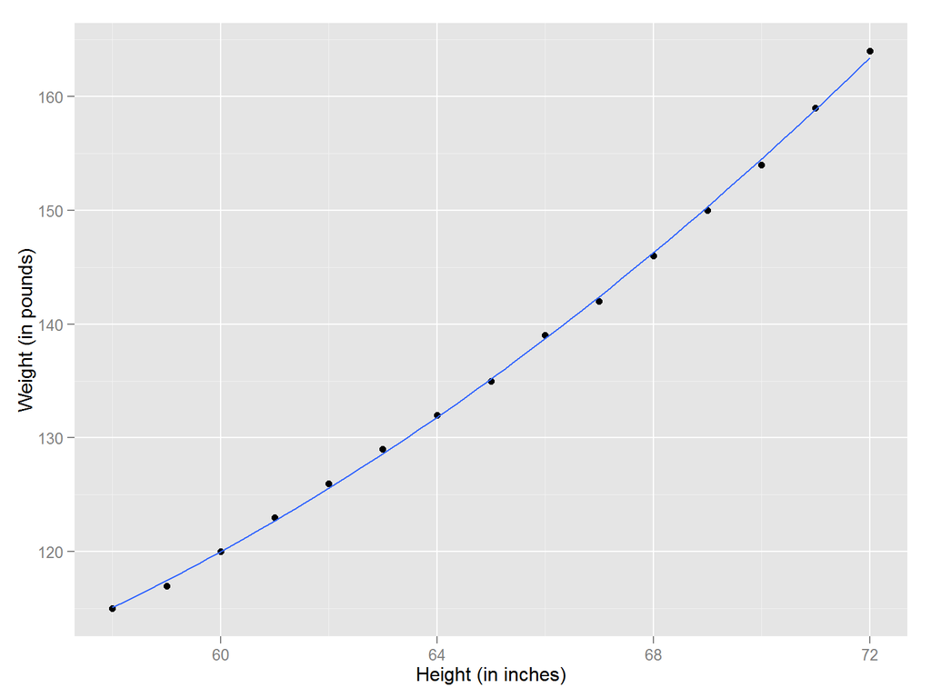

```r
qplot(height, weight, data = women, geom = c("point", "smooth"), method = "lm",
    formula = y ~ x + I(x^2), se = FALSE, xlab = "Height (in inches)", ylab = "Weight (in pounds)")
```

# Polynomial regression

- In general, an nth degree polynomial produces a curve with n-1 bends.
- To fit a cubic polynomial, you’d use

  ```r
  fit3 = lm(weight ~ height + I(height^2) + I(height^3), data = women)
  ```

- Although higher polynomial are possible, I’ve rarely found that terms higher than cubic are necessary.

# Multiple linear regression

- When there’s more than one predictor variable, simple linear regression becomes multiple linear regression, and the analysis grows more involved.
- We want to explore the relationship between a state’s murder rate and other characteristics of the state.

  ```r
  states = as.data.frame(state.x77[, c("Murder", "Population", "Illiteracy", "Income",
      "Frost")])
  cor(states)
  ```

  ```
  ##             Murder Population Illiteracy  Income   Frost
  ## Murder      1.0000     0.3436     0.7030 -0.2301 -0.5389
  ## Population  0.3436     1.0000     0.1076  0.2082 -0.3322
  ## Illiteracy  0.7030     0.1076     1.0000 -0.4371 -0.6719
  ## Income     -0.2301     0.2082    -0.4371  1.0000  0.2263
  ## Frost      -0.5389    -0.3322    -0.6719  0.2263  1.0000
  ```

# Multiple linear regression

```r
fit = lm(Murder ~ Population + Illiteracy + Income + Frost, data = states)
summary(fit)
```

```
##
## Call:
## lm(formula = Murder ~ Population + Illiteracy + Income + Frost,
##     data = states)
##
## Residuals:
##    Min     1Q Median     3Q    Max
## -4.796 -1.649 -0.081  1.482  7.621
##
## Coefficients:
##             Estimate Std. Error t value Pr(>|t|)
## (Intercept) 1.23e+00   3.87e+00    0.32    0.751
## Population  2.24e-04   9.05e-05    2.47    0.017 *
## Illiteracy  4.14e+00   8.74e-01    4.74  2.2e-05 ***
## Income      6.44e-05   6.84e-04    0.09    0.925
## Frost       5.81e-04   1.01e-02    0.06    0.954
## ---
## Signif. codes:  0 '***' 0.001 '**' 0.01 '*' 0.05 '.' 0.1 ' ' 1
##
## Residual standard error: 2.53 on 45 degrees of freedom
## Multiple R-squared:  0.567,  Adjusted R-squared:  0.528
## F-statistic: 14.7 on 4 and 45 DF,  p-value: 9.13e-08
```

# Multiple linear regression with interactions

- Some of the most interesting research findings are those involving interactions among predictor variables.
- Consider the automobile data in the `mtcars` data frame.
- Let’s say you’re interested in the impact of automobile weight and horse power on mileage.

# Multiple linear regression with interactions

```r
fit = lm(mpg ~ hp + wt + hp:wt, data = mtcars)
summary(fit)
```

```
##
## Call:
## lm(formula = mpg ~ hp + wt + hp:wt, data = mtcars)
##
## Residuals:
##    Min     1Q Median     3Q    Max
## -3.063 -1.649 -0.736  1.421  4.551
##
## Coefficients:
##             Estimate Std. Error t value Pr(>|t|)
## (Intercept) 49.80842    3.60516   13.82  5.0e-14 ***
## hp          -0.12010    0.02470   -4.86  4.0e-05 ***
## wt          -8.21662    1.26971   -6.47  5.2e-07 ***
## hp:wt        0.02785    0.00742    3.75  0.00081 ***
## ---
## Signif. codes:  0 '***' 0.001 '**' 0.01 '*' 0.05 '.' 0.1 ' ' 1
##
## Residual standard error: 2.15 on 28 degrees of freedom
## Multiple R-squared:  0.885,  Adjusted R-squared:  0.872
## F-statistic: 71.7 on 3 and 28 DF,  p-value: 2.98e-13
```

# Multiple linear regression with interactions

- To interpret the interaction, you can plug in various values of wt and simplify the equation.

  ```r
  wt = c(2.2, 3.2, 4.2)
  df = expand.grid(hp = mtcars$hp, wt = wt)
  df$mpg = predict(fit, df)
  head(df)
  ```

  ```
  ##    hp  wt   mpg
  ## 1 110 2.2 25.26
  ## 2 110 2.2 25.26
  ## 3  93 2.2 26.26
  ## 4 110 2.2 25.26
  ## 5 175 2.2 21.44
  ## 6 105 2.2 25.55
  ```

# Multiple linear regression with interactions

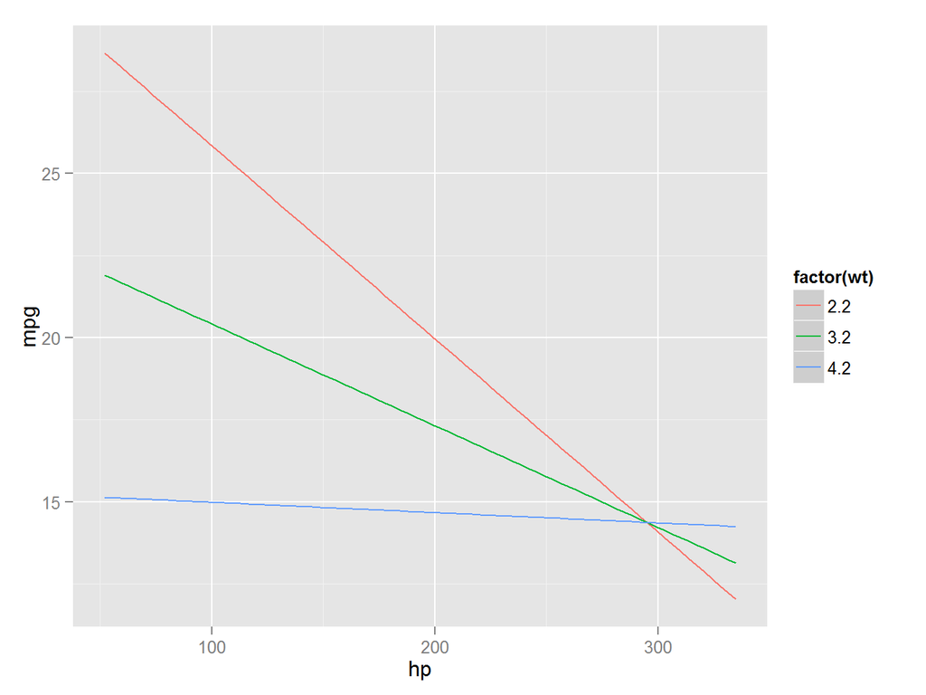

```r
qplot(hp, mpg, data = df, colour = factor(wt), geom = "smooth", method = "lm")
```